# The Impact of k on endemicity

### Functions

Include function for calculating median incidence for last 100 generations:

Include function for calculating the proportion of simulations which become endemic for a given parameter set.

### What is the impact of transmission heterogeneity on endemicity?

#### Model Parameters:

- Explore variable levels of heterogeneity from k = 0.1 to k = Inf
  - *see negative binomial distribution plot for explanation of k parameter*
- Explore model behaviour over a range of values for R0 and refractory periods to understand how the parameters interact.
- Include reseeding to prevent early stochastic die-out
- Run for 1000 generations to observe long term trajectory

#### The k parameter

- The negative binomial distribution is used to describe the distribution of $v$ the individual reproduction number (effective contact rate of units)
- Following Lloyd-Smith *et al.* (2005), $v$ is gamma-distributed with mean R0 and dispersion parameter k. The number of secondary infections caused by each case, $Z$ is described by offxpring distribution $Z∼ negativebinomial(R0,k)$
- $R0$ is defined as the mean number of infections caused by a signle infected individual in an entirely susceptible population
- $k$ provides a measure of dispersion around the mean $R0$, where smaller values of $k$ indicate greater heterogeneity (Lloyd-Smith *et al.* 2005)
  - The Poisson ($k\to\infty$) and geometric ($k = 1$) models are special cases of the negative binomial distribution.
  - $k\to\infty$ : in generation-based models neglecting individual variation, $v = R0$ for all cases, yielding $Z∼Poisson(R0)$
  - $k = 1$ : in differential-equation models with homogeneous transmission and constant recovery rates, $v$ is exponentially distributed, yielding $Z∼geometric(R0)$
- The plot below shows the proportion of cases accounted for by the top 10% of infectious units under different values of $k$.

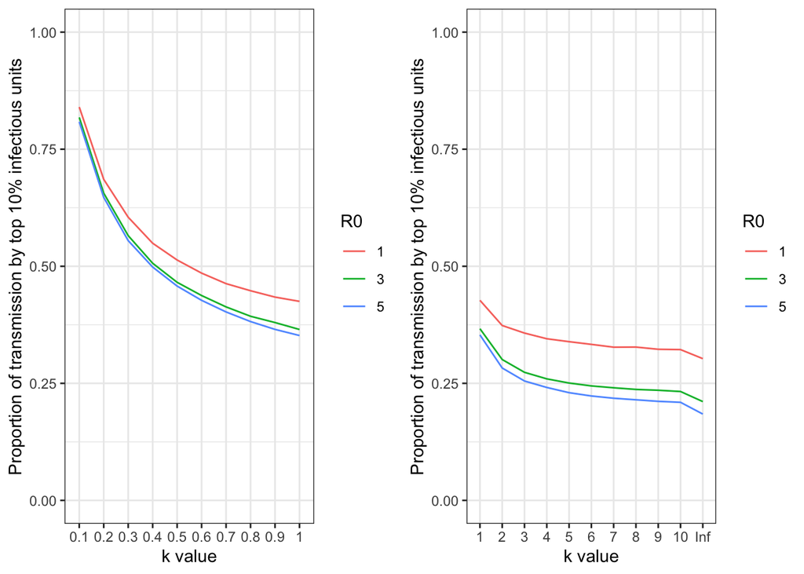

### The Impact of Heterogeneity on Incidence and Endemicity:

#### Plot 1 : Median Incidence at Equilibrium

A plot which shows the median incidence and IQR (from generation 900-1000) for different values of R0 (x axis), Refractory Period (facets), and k parameters (lines).

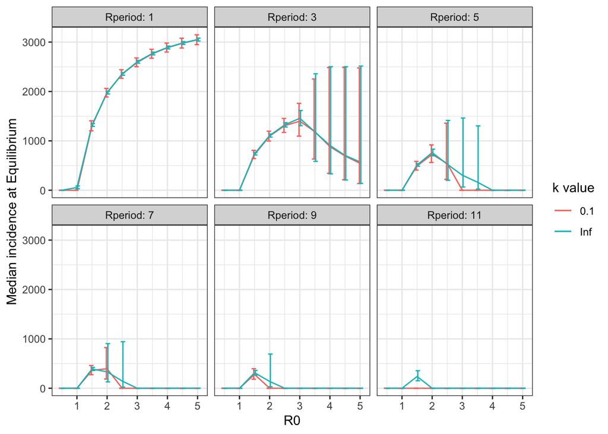

**What is the impact of $k$ on the median incidence at equilibrium (after 900generations)?**

- For most $R0$ and refractory period combinations, the trend in median incidence observed is robust to changes in the value of $k$ (level of heterogeneity), with only small differences observed between the most extreme k values ( $k = 0.1; k=\infty$)
  - For refractory periods > 5 generations, extinction occurs at lower values of $R0$ when $k = 0.1$ (high heterogeneity) compared to $k = \infty$ (homogeneity)
- For values of $R0$ lower than the threshold $R0$ (corresponding to maximum incidence), variation around the median incidence is greater when $k = 0.1$ (high heterogeneity) compared to $k = \infty$ (homogeneity).
  - At values of $R0$ above the threshold the variation around the median incidence is similar when $k = 0.1$ (high heterogeneity) and $k = \infty$ (homogeneity).

**Why is there greater variation for lower k values?**

- As seen in the plot below, when the population has a high level of heterogeneity (k = 0.1) there is greater variation around the median incidence, a pattern which is conserved long-term (10,000 generations).
- The high level of heterogeneity between units in terms of transmission potential explains this pattern. Stochasticity in the infection process means that at some time points the majority of new infections may be high-contact units - driving a rapid increase in incidence, whilst at other timepoints the majority of new infections may be units with few, or no, contacts - resulting in a decline to very low incidence.
- The lower variation around median incidence in the k = Inf scenario, reflects the increased homogeneity of the population, with less variation in unit contact rates resulting in oscillation over a narrow range of incidence.

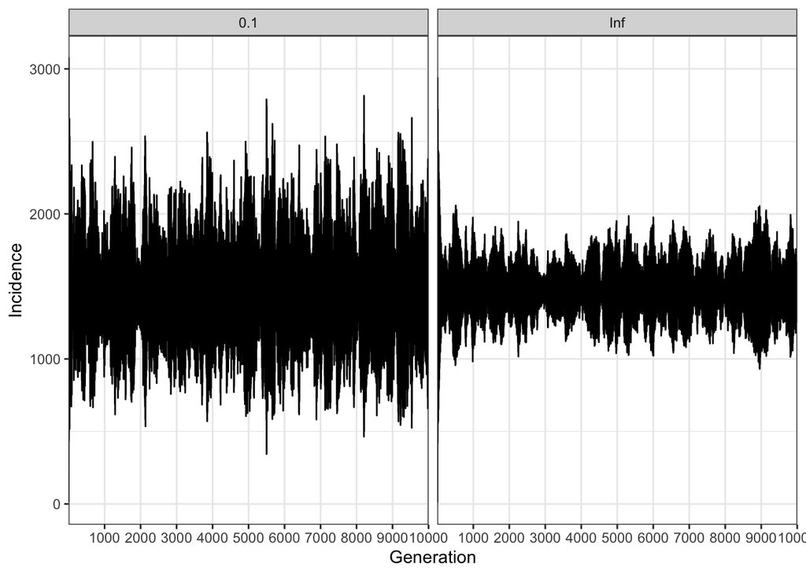

#### Plot 2 : Proportion of simulations which become endemic

The plot shows how different values of Refractory Period (x axis), $R0$ (facets) and $k$ (lines) impact the proportion of simulations resulting in endemicity.

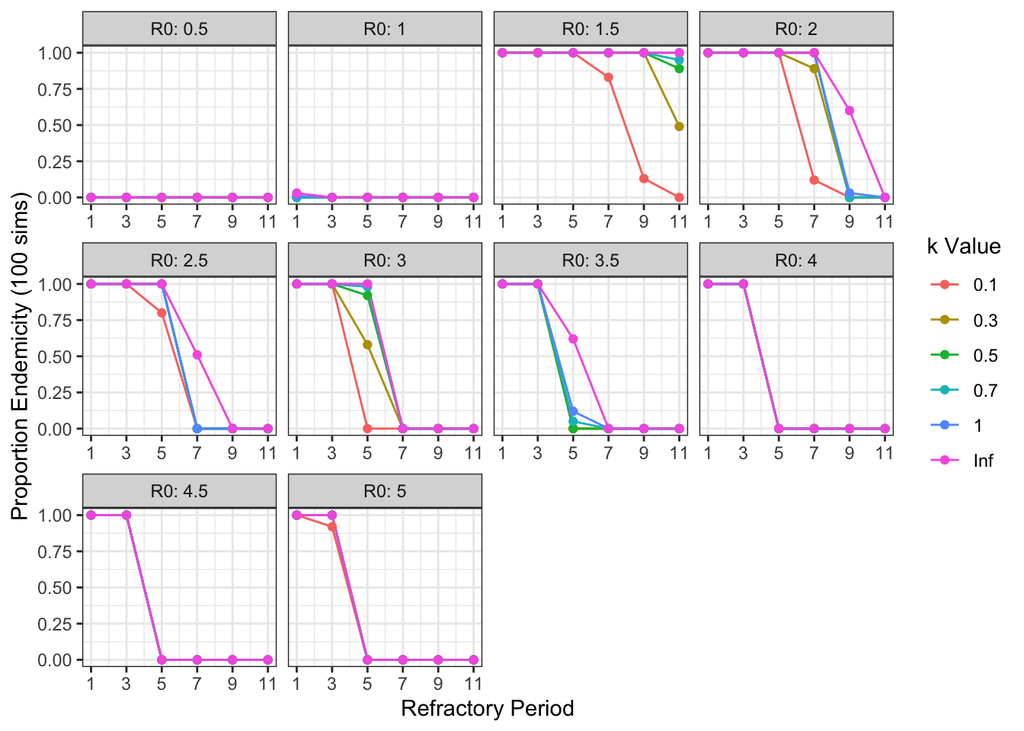

**What is the impacts of $k$ on the proportion of simulations which result in extinction?**

For $R0 < 1$ :

- All simulations result in extinction

Between $R0 = 1.5$ and $R0 = 3.5$

- For a given $R0$ and refractory period combination, as the value of $k$ decreases (population becomes more heterogeneous), the proportion of simulations which result in extinction increases.
- For a given $R0$, the threshold beyond which a proportion of simulations result in extinction occurs at shorter refractory periods as $k$ decreases (population heterogeneity increases).

For $R0 > 4$

- The trend in endemicity as the refractory period increases is unaffected by changes in the $k$ parameter (population heterogeneity)

In general:

- For a given set of parameters ($R0$, Refractory Period), the likelihood of extinction increases as population heterogeneity increases.
- From Lloyd-Smith *et al.* (2005):
  - *“Extinction risk rises owing to a higher proportion of non-transmitting cases when $v$ (individual reproduction number) is overdispersed”*
  - *“This effect thwarts invasion by diseases that are very potent spreaders on average: for arbitrarily high R0* $q \to\ 1$ (q = extinction probability) *as* $k\to\0$”

**Why does the probability of extinction increase with decreasing k value?**

- For the parameter set: $R0 = 2, R\_period = 7$ the plots below the epidemic trajectory of multiple simulations for different k values.
- The plot shows that for lower values of k there is greater variation in incidence, with very high and low incidences apparent at different timepoints (see above for explanation).
- For all k parameter scenarios the epidemic is oscillatory, with rapid increases (epidemic peak) and decreases (epidemic troughs) in incidence.
  - During epidemic troughs, extinction is possible due to the sequential infection of low(/zero)-contact individuals (in this case assuming depletion of susceptibles is not the limiting factor- verified 150221).
  - In a heterogeneous population, there is a greater proportion of low/no-contact units and thus the probability of stochastic extinction is increased.

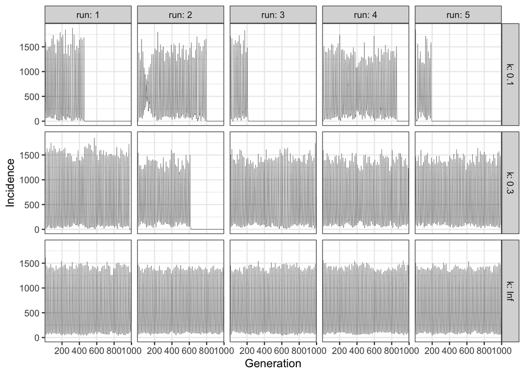